# Predicting Whether or Not an Employee Will Quit

## Introduction

Many companies often lose some of their best employees due to low satisfactory levels or unsatisfactory working conditions. Often when employees are unhappy, they will jump ship and move on to the next job. Some employees quit without any indication, while others it was a long time coming.

## Problem

For many companies, losing employees is a costly problem, especially if the employee is highly valued. Each time an employee quits, another one must be hired and trained, if the newly trained employee highly productive great, if not they have to repeat the process which is a strain on productivity.

Our goal in this analysis is to predict whether employees will stay or quit. This method type of analysis can help companies predict whether or not their top performing employees will stay or go.

## Data Set

The data set for this analysis focuses on the statistics gathered by human resources on employees that have quit and and currently employees.

Employee action is to quit or stay. Left (0 = stay, 1 = quit)

Here are the factors included by the HR stats.

- Satisfaction_level, employee’s satisfaction level at work, ranging between 0 and 1.
- Last_evaluation, company’s last evaluation of an employee, ranging between 0 and 1.
- Number_project, the number of projects handled by the employee.
- Average_monthly_hours, the average montly hours worked by the employee.
- Time_spend_company, number of years the employee has worked for the company.
- Work_accident, whether or not the employee expereience a workplace accident.
- Promotion_last_5year, whether the employee has been promoted in 5 years (0 = no, 1 = yes)
- Job_category, 10 levels of different jobs offered by the company.
- Salary, 3 levels of salary, low, medium and high.

## Data Limitations

Instead of including the exact amount of salary, the data set only includes a factor with 3 levels. If the exact salary were provided, the company could have a more accurate analysis. Also, including salary amount can help the company while negotiating. Instead of a range of between “low and medium” they could have an exact amount predicted to offer their employee for them to stay.

The data set is very straight forward and could include other factors that affect the workplace. For example, employee altercations or commute to work distance. These these other factors could help provide a better analysis of whether or not an employee will leave their job.

## Data Wrangling

The data did not contain any missing values. The only adjustments made were a column name change because “sales” does not correctly show what the column contained, which is “job_category.” Also, three of the independent variables needed to be readjusted to be factors, so that they correctly reflect the levels represented.

```r
#Add data set to workspace and name it hr_stat. Check data.
hr_stat <- read.csv("HR_comma_sep.csv")
summary(hr_stat)
```

```
##  satisfaction_level last_evaluation  number_project  average_montly_hours
##  Min.   :0.0900     Min.   :0.3600   Min.   :2.000   Min.   : 96.0
##  1st Qu.:0.4400     1st Qu.:0.5600   1st Qu.:3.000   1st Qu.:156.0
##  Median :0.6400     Median :0.7200   Median :4.000   Median :200.0
##  Mean   :0.6128     Mean   :0.7161   Mean   :3.803   Mean   :201.1
##  3rd Qu.:0.8200     3rd Qu.:0.8700   3rd Qu.:5.000   3rd Qu.:245.0
##  Max.   :1.0000     Max.   :1.0000   Max.   :7.000   Max.   :310.0
##
##  time_spend_company Work_accident         left
##  Min.   : 2.000     Min.   :0.0000   Min.   :0.0000
##  1st Qu.: 3.000     1st Qu.:0.0000   1st Qu.:0.0000
##  Median : 3.000     Median :0.0000   Median :0.0000
##  Mean   : 3.498     Mean   :0.1446   Mean   :0.2381
##  3rd Qu.: 4.000     3rd Qu.:0.0000   3rd Qu.:0.0000
##  Max.   :10.000     Max.   :1.0000   Max.   :1.0000
##
##  promotion_last_5years         sales         salary
##  Min.   :0.00000       sales      :4140   high  :1237
##  1st Qu.:0.00000       technical  :2720   low   :7316
##  Median :0.00000       support    :2229   medium:6446
##  Mean   :0.02127       IT         :1227
##  3rd Qu.:0.00000       product_mng: 902
##  Max.   :1.00000       marketing  : 858
##                        (Other)    :2923
```

```r
#Check for missing values.
summary(is.na(hr_stat))
```

```
##  satisfaction_level last_evaluation number_project  average_montly_hours
##  Mode :logical      Mode :logical   Mode :logical   Mode :logical
##  FALSE:14999        FALSE:14999     FALSE:14999     FALSE:14999
##  time_spend_company Work_accident      left         promotion_last_5years
##  Mode :logical      Mode :logical   Mode :logical   Mode :logical
##  FALSE:14999        FALSE:14999     FALSE:14999     FALSE:14999
##    sales           salary
##  Mode :logical   Mode :logical
##  FALSE:14999     FALSE:14999
```

```r
#Rename "Sales" to job_category as it can be confusing.
hr_stat <- hr_stat %>%
  rename(job_category = sales)

#Change "left", "Work_accident" and "promotion_last_5years" to a factor of 0 and 1, 1 being Yes 0 being No.
hr_stat$left <- factor(hr_stat$left)
hr_stat$promotion_last_5years <- factor(hr_stat$promotion_last_5years)
hr_stat$Work_accident <- factor(hr_stat$Work_accident)

str(hr_stat)
```

```
## 'data.frame':    14999 obs. of  10 variables:
##  $ satisfaction_level   : num  0.38 0.8 0.11 0.72 0.37 0.41 0.1 0.92 0.89 0.42 ...
##  $ last_evaluation      : num  0.53 0.86 0.88 0.87 0.52 0.5 0.77 0.85 1 0.53 ...
##  $ number_project       : int  2 5 7 5 2 2 6 5 5 2 ...
##  $ average_montly_hours : int  157 262 272 223 159 153 247 259 224 142 ...
##  $ time_spend_company   : int  3 6 4 5 3 3 4 5 5 3 ...
##  $ Work_accident        : Factor w/ 2 levels "0","1": 1 1 1 1 1 1 1 1 1 1 ...
##  $ left                 : Factor w/ 2 levels "0","1": 2 2 2 2 2 2 2 2 2 2 ...
##  $ promotion_last_5years: Factor w/ 2 levels "0","1": 1 1 1 1 1 1 1 1 1 1 ...
##  $ job_category         : Factor w/ 10 levels "accounting","hr",..: 8 8 8 8 8 8 8 8 8 8 ...
##  $ salary               : Factor w/ 3 levels "high","low","medium": 2 3 3 2 2 2 2 2 2 2 ...
```

```r
#Change salary to ordered()
hr_stat$salary <- ordered(hr_stat$salary, c("low","medium","high"))
```

## Preliminary Analysis

In the premliminary analysis we want to explore each of the independent variables and their relationship to those who left and who stayed.

#### Satisfaction Level

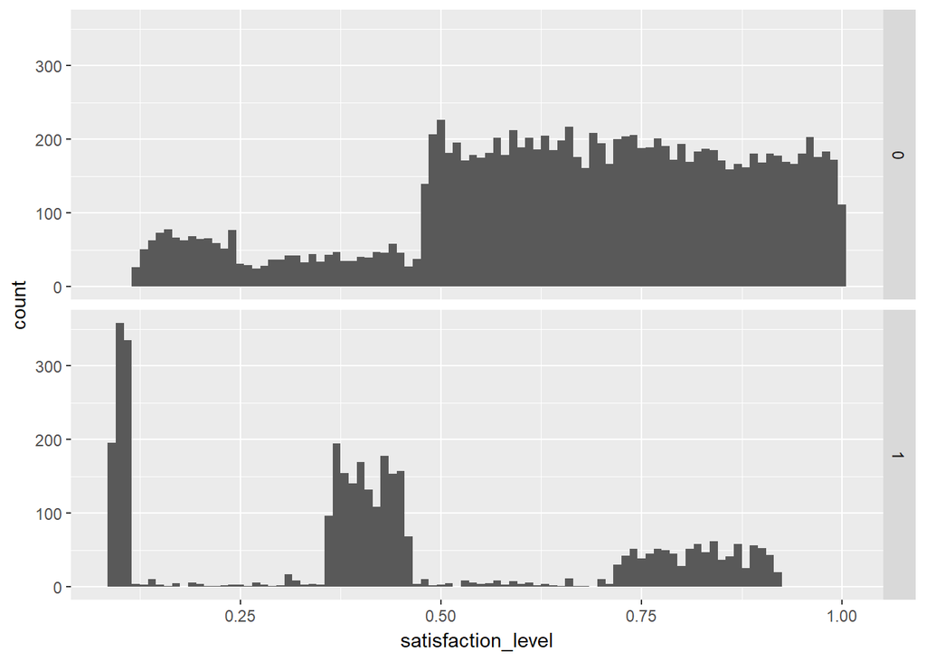

```r
ggplot(hr_stat, aes(satisfaction_level)) + geom_histogram(binwidth = 0.01) + facet_grid(left ~.)
```

The plot indicates that most employees who left have a low satisfaction level. Although, there are still employees quitting with high satisfaction levels. From the individuals who stayed, we can see a general trend of having 50% or higher satisfaction.

#### Last Evaluation

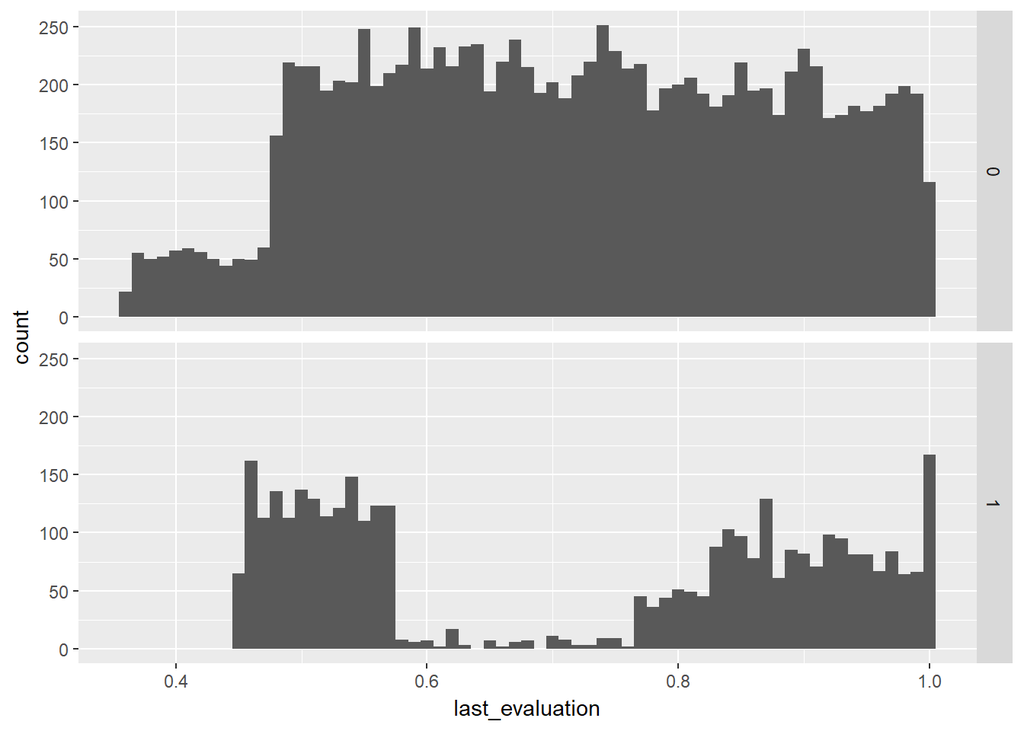

```r
ggplot(hr_stat, aes(last_evaluation)) + geom_histogram(binwidth = 0.01) + facet_grid(left ~.)
```

#### Number of Projects

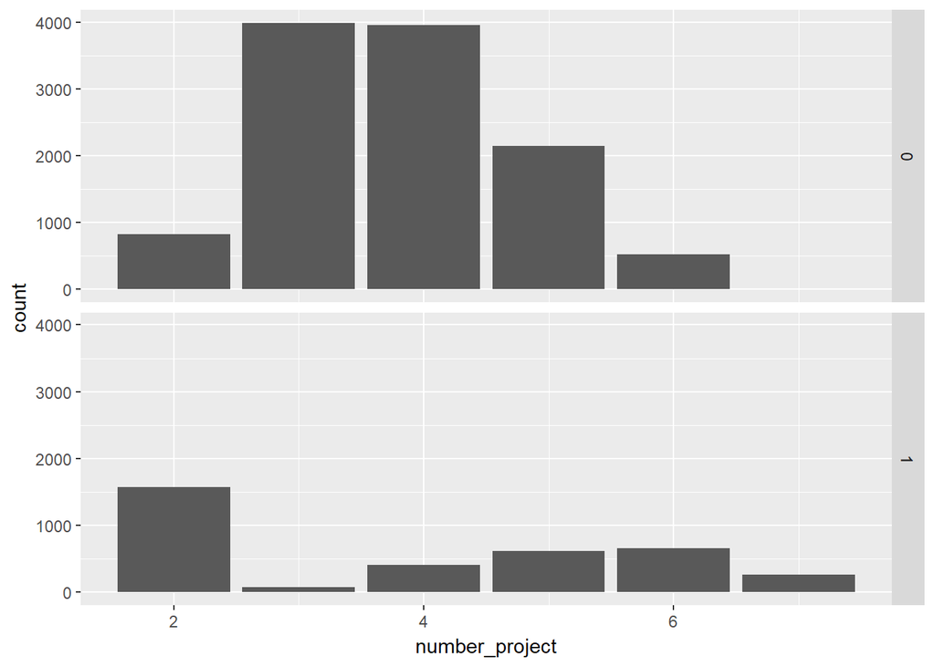

```r
ggplot(hr_stat, aes(number_project)) + geom_bar(stat = "count") + facet_grid(left ~.)
```

#### Average Montly Hours Worked

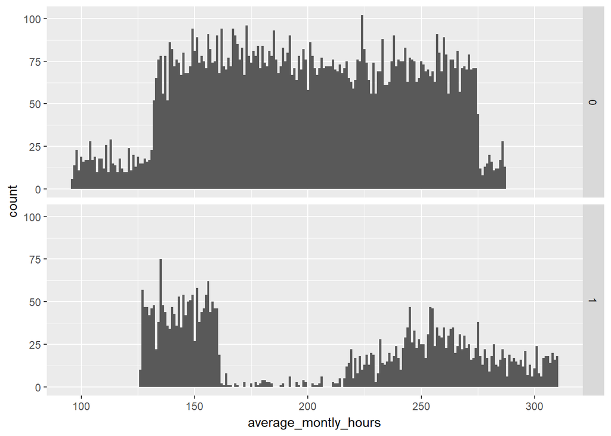

```r
ggplot(hr_stat, aes(average_montly_hours)) + geom_histogram(binwidth = 1) + facet_grid(left ~.)
```

Many employees who left either worked under 200 hours or above 250. Comparing with those who stayed, many employees were working almost 300 hours, above the amount of those who stayed, whi is below 300 hours.

#### Time spent at company

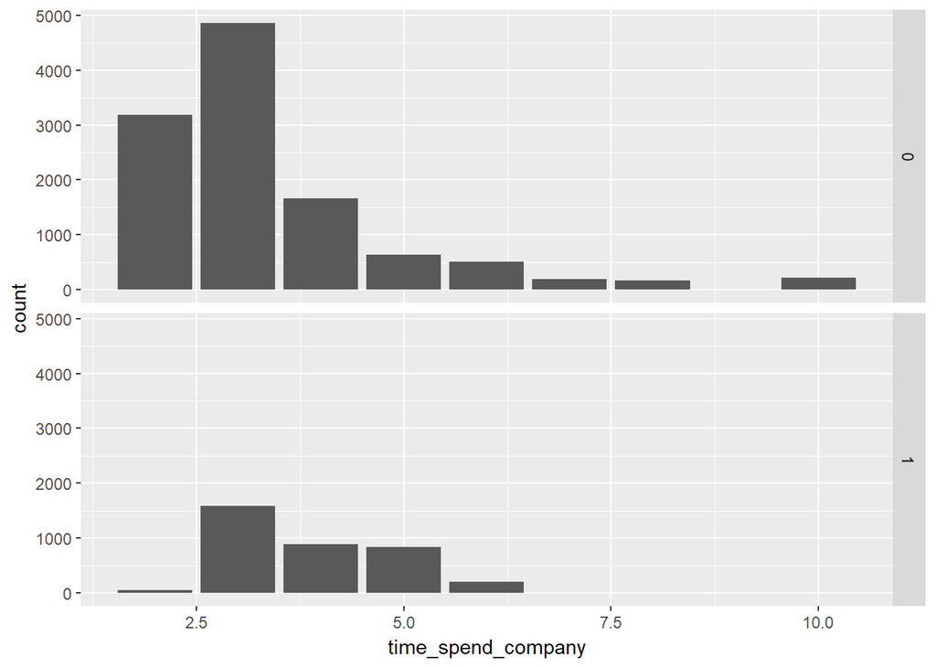

```r
ggplot(hr_stat, aes(time_spend_company)) + geom_bar() + facet_grid(left ~.)
```

Of the employees that left most left under 5 Years. WHich could be a deciding point for employees when evaluating if they should quit or stay at a company.

#### Promotions

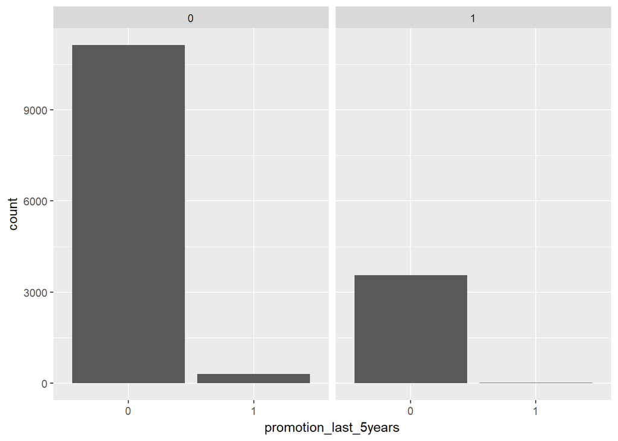

```r
ggplot(hr_stat, aes(promotion_last_5years)) + geom_bar() + facet_grid(. ~ left)
```

From this table we see that individuals who left were not offered a promotion in the last 5 years. This table could indicate that because no promotion was offered an individual quit. However, we need to keep in mind, many individuals quit prior to hitting their 5 year mark, thus the variable may not be realistic in evaluating an employee and can be improved by less than 5 year evaluation.

#### Salary

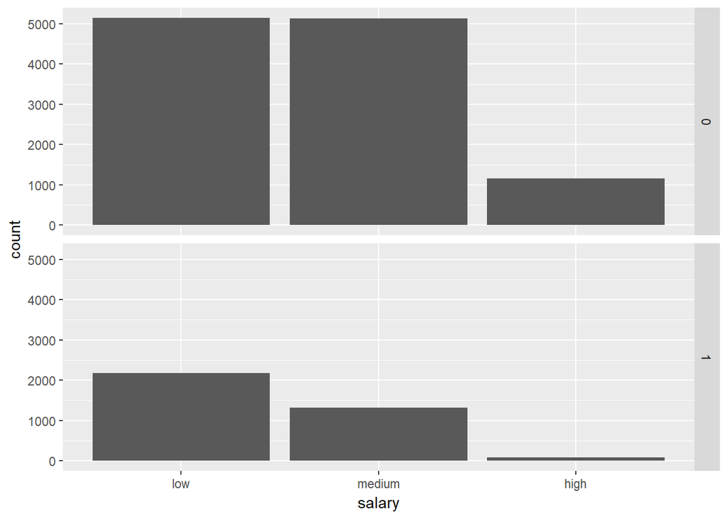

```r
ggplot(hr_stat, aes(salary)) + geom_bar() + facet_grid(left ~.)
```

## Machine Learning

Now that we have a general view of the variables in relation to quitting or staying, we will use machine learning methods to try and build models to predict whether or not an individual will quit or stay at their job. We will use three different methods to build models, a logistic regression model, classification and regression tree, and a random forest model.

### Logistic Regression

First divide the data into a training set and testing set. The training set will be used to make our logistic regression model, while our testing set will be used to test the accuracy of our regression model.

For our training set, we used 75% of the observations while the remaining will be in our testing set.

```r
#Split data into training and testing.
set.seed(1234)
divide = sample.split(hr_stat, SplitRatio = 0.75)
hr_stat_training = subset(hr_stat, divide == TRUE)
hr_stat_test = subset(hr_stat, divide == FALSE)

#Check the split of data for percentage. Should be approximately 75%
nrow(hr_stat_training)
```

```
## [1] 10499
```

```r
nrow(hr_stat_training)/nrow(hr_stat)
```

```
## [1] 0.69998
```

We ended up with a 70% and 30% Since our data set is large it should not be an issue.

Now we use our training model to run a logistical regression model. Then from that model we will remove any variables that do no show significance.

```r
model1 <- glm(left ~ ., data = hr_stat_training, family = binomial)
summary(model1)
```

```
##
## Call:
## glm(formula = left ~ ., family = binomial, data = hr_stat_training)
##
## Deviance Residuals:
##     Min       1Q   Median       3Q      Max
## -2.1861  -0.6631  -0.4048  -0.1216   3.0655
##
## Coefficients:
##                           Estimate Std. Error z value Pr(>|z|)
## (Intercept)             -0.3923846  0.1844040  -2.128 0.033349 *
## satisfaction_level      -4.1399026  0.1171923 -35.326  < 2e-16 ***
## last_evaluation          0.8066603  0.1792679   4.500 6.80e-06 ***
## number_project          -0.3218998  0.0256281 -12.560  < 2e-16 ***
## average_montly_hours     0.0045140  0.0006164   7.323 2.43e-13 ***
## time_spend_company       0.2607978  0.0184872  14.107  < 2e-16 ***
## Work_accident1          -1.4813980  0.1059685 -13.980  < 2e-16 ***
## promotion_last_5years1  -1.4376200  0.3096515  -4.643 3.44e-06 ***
## job_categoryhr           0.2345076  0.1579529   1.485 0.137632
## job_categoryIT          -0.1004455  0.1470809  -0.683 0.494653
## job_categorymanagement  -0.3027015  0.1902336  -1.591 0.111562
## job_categorymarketing    0.1054093  0.1582669   0.666 0.505397
## job_categoryproduct_mng -0.0791575  0.1564702  -0.506 0.612930
## job_categoryRandD       -0.6394020  0.1760604  -3.632 0.000282 ***
## job_categorysales       -0.0161270  0.1235454  -0.131 0.896143
## job_categorysupport      0.1267998  0.1315192   0.964 0.334988
## job_categorytechnical    0.1196931  0.1286373   0.930 0.352128
## salary.L                -1.2928204  0.1073446 -12.044  < 2e-16 ***
## salary.Q                -0.3085470  0.0702494  -4.392 1.12e-05 ***
## ---
## Signif. codes:  0 '***' 0.001 '**' 0.01 '*' 0.05 '.' 0.1 ' ' 1
##
## (Dispersion parameter for binomial family taken to be 1)
##
##     Null deviance: 11526  on 10498  degrees of freedom
## Residual deviance:  9015  on 10480  degrees of freedom
## AIC: 9053
##
## Number of Fisher Scoring iterations: 5
```

```r
model2 <- glm(left ~ . -job_category,  data = hr_stat_training, family = binomial)
summary(model2)
```

```
##
## Call:
## glm(formula = left ~ . - job_category, family = binomial, data = hr_stat_training)
##
## Deviance Residuals:
##     Min       1Q   Median       3Q      Max
## -2.1797  -0.6652  -0.4091  -0.1269   3.0746
##
## Coefficients:
##                          Estimate Std. Error z value Pr(>|z|)
## (Intercept)            -0.3824144  0.1487681  -2.571   0.0102 *
## satisfaction_level     -4.1311303  0.1166831 -35.405  < 2e-16 ***
## last_evaluation         0.8002494  0.1786024   4.481 7.44e-06 ***
## number_project         -0.3220897  0.0255426 -12.610  < 2e-16 ***
## average_montly_hours    0.0045335  0.0006145   7.378 1.61e-13 ***
## time_spend_company      0.2554444  0.0182709  13.981  < 2e-16 ***
## Work_accident1         -1.4855822  0.1058251 -14.038  < 2e-16 ***
## promotion_last_5years1 -1.4760850  0.3072250  -4.805 1.55e-06 ***
## salary.L               -1.3219585  0.1063158 -12.434  < 2e-16 ***
## salary.Q               -0.3205421  0.0697733  -4.594 4.35e-06 ***
## ---
## Signif. codes:  0 '***' 0.001 '**' 0.01 '*' 0.05 '.' 0.1 ' ' 1
##
## (Dispersion parameter for binomial family taken to be 1)
##
##     Null deviance: 11525.8  on 10498  degrees of freedom
## Residual deviance:  9058.4  on 10489  degrees of freedom
## AIC: 9078.4
##
## Number of Fisher Scoring iterations: 5
```

Using ANOVA, lets test model1 against model2.

```r
anova(model1, model2, test = "Chisq")
```

```
## Analysis of Deviance Table
##
## Model 1: left ~ satisfaction_level + last_evaluation + number_project +
##     average_montly_hours + time_spend_company + Work_accident +
##     promotion_last_5years + job_category + salary
## Model 2: left ~ (satisfaction_level + last_evaluation + number_project +
##     average_montly_hours + time_spend_company + Work_accident +
##     promotion_last_5years + job_category + salary) - job_category
##   Resid. Df Resid. Dev Df Deviance  Pr(>Chi)
## 1     10480     9015.0
## 2     10489     9058.4 -9  -43.335 1.871e-06 ***
## ---
## Signif. codes:  0 '***' 0.001 '**' 0.01 '*' 0.05 '.' 0.1 ' ' 1
```

Now that we have our most accurate model, lets test how accurate our model is against the testing data subset.

```r
#Test accuracy of our model.
predictiontest = predict(model1, type = "response", newdata = hr_stat_test)
table(hr_stat_test$left, predictiontest > 0.5)
```

```
##
##     FALSE TRUE
##   0  3213  216
##   1   698  373
```

```r
model1accuracy = (3213 + 373)/(698+373+3213+216)
model1accuracy
```

```
## [1] 0.7968889
```

From our table we see that our model1 correctly predicted that 3213 employees will stay, and 373 employees will quit. On the otherhand it mispredicted 216 + 698 employees decisions. By dividing correct predictions against total predictions our model was 79.69% accurate in predicting our test data.